# AMEC 2026 | Indiana University School of Medicine

R for SNMA

Mirindi Kabangu

## Instructor

Mirindi Kabangu

## Scope

Taming the Data Beast, by Allison Horst

## Overview

## The “Real-World” Medical Researcher Problem

You are a resident on a busy clinical rotation. You’ve been handed a messy Vital Signs log from a 3-patient pilot study.

```r
print(messy_vitals)
```

```
# A tibble: 3 × 3
  patient           bp     temp
  <chr>             <chr>  <chr>
1 Gemma Dunn        128/78 98.6F
2 Priscilla Holding 148/92 101.2F
3 Aniya Warner      115/73 97.5F
```

```r
messy_vitals |>
  # Separate BP into two numbers
  separate(bp, into = c("sys", "dia"), sep = "/")
```

```
# A tibble: 3 × 4
  patient           sys   dia   temp
  <chr>             <chr> <chr> <chr>
1 Gemma Dunn        128   78    98.6F
2 Priscilla Holding 148   92    101.2F
3 Aniya Warner      115   73    97.5F
```

```r
messy_vitals |>
  # Separate BP into two numbers
  separate(bp, into = c("sys", "dia"), sep = "/") |>
  # Clean Temp units
  mutate(temp = parse_number(temp))
```

```
# A tibble: 3 × 4
  patient           sys   dia    temp
  <chr>             <chr> <chr> <dbl>
1 Gemma Dunn        128   78     98.6
2 Priscilla Holding 148   92    101.
3 Aniya Warner      115   73     97.5
```

```r
messy_vitals |>
  # Separate BP into two numbers
  separate(bp, into = c("sys", "dia"), sep = "/") |>
  # Clean Temp units
  mutate(temp = parse_number(temp)) |>
  # Convert types
  mutate(across(c(sys, dia), as.numeric))
```

```
# A tibble: 3 × 4
  patient             sys   dia  temp
  <chr>             <dbl> <dbl> <dbl>
1 Gemma Dunn          128    78  98.6
2 Priscilla Holding   148    92 101.
3 Aniya Warner        115    73  97.5
```

```r
messy_vitals |>
  # Separate BP into two numbers
  separate(bp, into = c("sys", "dia"), sep = "/") |>
  # Clean Temp units
  mutate(temp = parse_number(temp)) |>
  # Convert types
  mutate(across(c(sys, dia), as.numeric)) |>
  # Add the Clinical Flag
  mutate(flag = sys >= 140)
```

```
# A tibble: 3 × 5
  patient             sys   dia  temp flag
  <chr>             <dbl> <dbl> <dbl> <lgl>
1 Gemma Dunn          128    78  98.6 FALSE
2 Priscilla Holding   148    92 101.  TRUE
3 Aniya Warner        115    73  97.5 FALSE
```

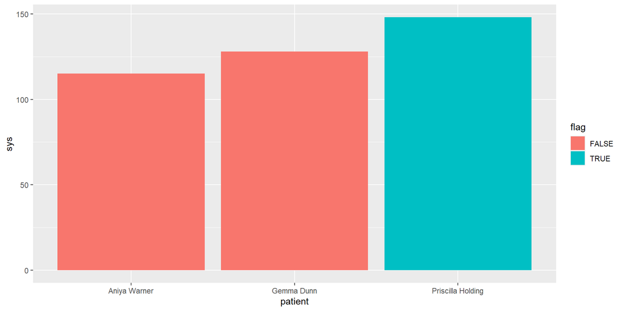

```r
messy_vitals |>
  # Separate BP into two numbers
  separate(bp, into = c("sys", "dia"), sep = "/") |>
  # Clean Temp units
  mutate(temp = parse_number(temp)) |>
  # Convert types
  mutate(across(c(sys, dia), as.numeric)) |>
  # Add the Clinical Flag
  mutate(flag = sys >= 140) |>
  # Instant Visualization
  ggplot(aes(x = patient, y = sys, fill = flag)) +
  geom_col()
```

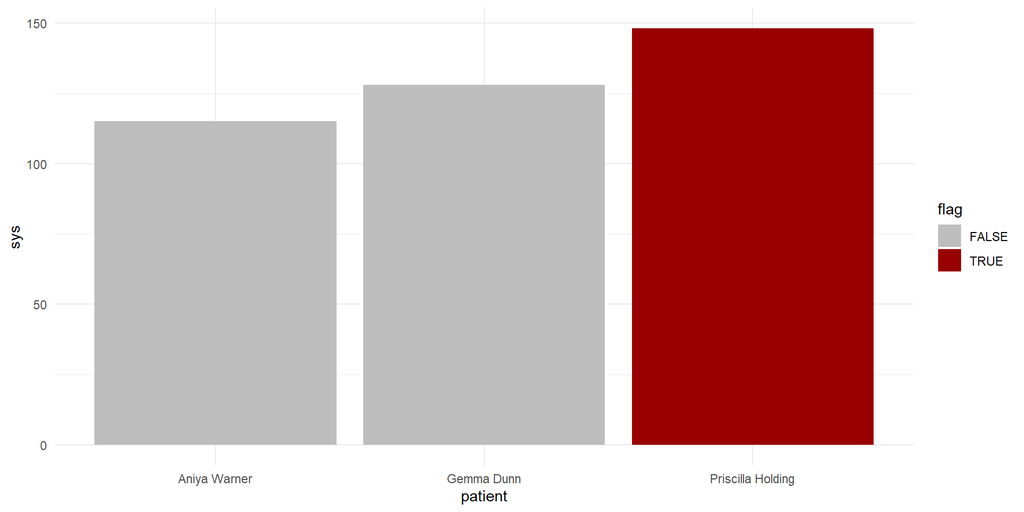

```r
messy_vitals |>
  # Separate BP into two numbers
  separate(bp, into = c("sys", "dia"), sep = "/") |>
  # Clean Temp units
  mutate(temp = parse_number(temp)) |>
  # Convert types
  mutate(across(c(sys, dia), as.numeric)) |>
  # Add the Clinical Flag
  mutate(flag = sys >= 140) |>
  # Instant Visualization
  ggplot(aes(x = patient, y = sys, fill = flag)) +
  geom_col() +
  scale_fill_manual(values = c("gray", "#990000")) + # IU Crimson!
  theme_minimal()
```

## Another Challenge

You are a resident on a busy clinical rotation. You’ve been handed a messy of cancer treatement data.

- The Data
- The Goal:
  - Download the CSV
  - Calculate the mean and standard deviations for each row
  - Calculate the p-values

```r
library(gtsummary)

# Use the built-in 'trial' clinical dataset
gtsummary::trial |>
  select(trt, age, grade, response) |>
  # Create the summary table
  tbl_summary()
```

| **Characteristic** | **N = 200**<sup>1</sup> |
| --- | --- |
| Chemotherapy Treatment |  |
| Drug A | 98 (49%) |
| Drug B | 102 (51%) |
| Age | 47 (38, 57) |
| Unknown | 11 |
| Grade |  |
| I | 68 (34%) |
| II | 68 (34%) |
| III | 64 (32%) |
| Tumor Response | 61 (32%) |
| Unknown | 7 |

<sup>1</sup> n (%); Median (Q1, Q3)

```r
library(gtsummary)

# Use the built-in 'trial' clinical dataset
gtsummary::trial |>
  select(trt, age, grade, response) |>
  # Create the summary table
  tbl_summary(
    by = trt, # Split by treatment group
  )
```

| **Characteristic** | **Drug A** N = 98<sup>1</sup> | **Drug B** N = 102<sup>1</sup> |
| --- | --- | --- |
| Age | 46 (37, 60) | 48 (39, 56) |
| Unknown | 7 | 4 |
| Grade |  |  |
| I | 35 (36%) | 33 (32%) |
| II | 32 (33%) | 36 (35%) |
| III | 31 (32%) | 33 (32%) |
| Tumor Response | 28 (29%) | 33 (34%) |
| Unknown | 3 | 4 |

<sup>1</sup> Median (Q1, Q3); n (%)

```r
library(gtsummary)

# Use the built-in 'trial' clinical dataset
gtsummary::trial |>
  select(trt, age, grade, response) |>
  # Create the summary table
  tbl_summary(
    by = trt, # Split by treatment group
    statistic = list(all_continuous() ~ "{mean} ({sd})")
  )
```

| **Characteristic** | **Drug A** N = 98<sup>1</sup> | **Drug B** N = 102<sup>1</sup> |
| --- | --- | --- |
| Age | 47 (15) | 47 (14) |
| Unknown | 7 | 4 |
| Grade |  |  |
| I | 35 (36%) | 33 (32%) |
| II | 32 (33%) | 36 (35%) |
| III | 31 (32%) | 33 (32%) |
| Tumor Response | 28 (29%) | 33 (34%) |
| Unknown | 3 | 4 |

<sup>1</sup> Mean (SD); n (%)

```r
library(gtsummary)

# Use the built-in 'trial' clinical dataset
gtsummary::trial |>
  select(trt, age, grade, response) |>
  # Create the summary table
  tbl_summary(
    by = trt, # Split by treatment group
    statistic = list(all_continuous() ~ "{mean} ({sd})")
  ) |>
  # Add statistical comparison (p-values)
  add_p()
```

| **Characteristic** | **Drug A** N = 98<sup>1</sup> | **Drug B** N = 102<sup>1</sup> | **p-value**<sup>2</sup> |
| --- | --- | --- | --- |
| Age | 47 (15) | 47 (14) | 0.7 |
| Unknown | 7 | 4 |  |
| Grade |  |  | 0.9 |
| I | 35 (36%) | 33 (32%) |  |
| II | 32 (33%) | 36 (35%) |  |
| III | 31 (32%) | 33 (32%) |  |
| Tumor Response | 28 (29%) | 33 (34%) | 0.5 |
| Unknown | 3 | 4 |  |

<sup>1</sup> Mean (SD); n (%)  
<sup>2</sup> Wilcoxon rank sum test; Pearson’s Chi-squared test

```r
library(gtsummary)

# Use the built-in 'trial' clinical dataset
gtsummary::trial |>
  select(trt, age, grade, response) |>
  # Create the summary table
  tbl_summary(
    by = trt, # Split by treatment group
    statistic = list(all_continuous() ~ "{mean} ({sd})")
  ) |>
  # Add statistical comparison (p-values)
  add_p() |>
  # Add a "Total" column
  add_overall()
```

| **Characteristic** | **Overall** N = 200<sup>1</sup> | **Drug A** N = 98<sup>1</sup> | **Drug B** N = 102<sup>1</sup> | **p-value**<sup>2</sup> |
| --- | --- | --- | --- | --- |
| Age | 47 (14) | 47 (15) | 47 (14) | 0.7 |
| Unknown | 11 | 7 | 4 |  |
| Grade |  |  |  | 0.9 |
| I | 68 (34%) | 35 (36%) | 33 (32%) |  |
| II | 68 (34%) | 32 (33%) | 36 (35%) |  |
| III | 64 (32%) | 31 (32%) | 33 (32%) |  |
| Tumor Response | 61 (32%) | 28 (29%) | 33 (34%) | 0.5 |
| Unknown | 7 | 3 | 4 |  |

<sup>1</sup> Mean (SD); n (%)  
<sup>2</sup> Wilcoxon rank sum test; Pearson’s Chi-squared test

```r
library(gtsummary)

# Use the built-in 'trial' clinical dataset
gtsummary::trial |>
  select(trt, age, grade, response) |>
  # Create the summary table
  tbl_summary(
    by = trt, # Split by treatment group
    label = list(
      age ~ "Patient Age",
      grade ~ "Tumor Grade",
      response ~ "Treatment Response"
    ),
    statistic = list(all_continuous() ~ "{mean} ({sd})")
  ) |>
  # Add statistical comparison (p-values)
  add_p() |>
  # Add a "Total" column
  add_overall() |>
  # Make it look professional
  bold_labels() |>
  modify_header(label = "**Variable**")
```

| **Variable** | **Overall** N = 200<sup>1</sup> | **Drug A** N = 98<sup>1</sup> | **Drug B** N = 102<sup>1</sup> | **p-value**<sup>2</sup> |
| --- | --- | --- | --- | --- |
| Patient Age | 47 (14) | 47 (15) | 47 (14) | 0.7 |
| Unknown | 11 | 7 | 4 |  |
| Tumor Grade |  |  |  | 0.9 |
| I | 68 (34%) | 35 (36%) | 33 (32%) |  |
| II | 68 (34%) | 32 (33%) | 36 (35%) |  |
| III | 64 (32%) | 31 (32%) | 33 (32%) |  |
| Treatment Response | 61 (32%) | 28 (29%) | 33 (34%) | 0.5 |
| Unknown | 7 | 3 | 4 |  |

<sup>1</sup> Mean (SD); n (%)  
<sup>2</sup> Wilcoxon rank sum test; Pearson’s Chi-squared test

# Your Turn

## Exercise

- Filter `penguins` so that it only shows penguins from the `island` of `Biscoe` (you’ll have to use the `island` variable). Assign it to `biscoe_penguins`.

## Exercise 1: Isolate High-Grade Tumors

The `blood_storage` dataset contains a `Grade` variable (1-4). Filter the data to show only the most aggressive tumors (Grade 4) and assign it to `high_grade_cancers`.

### Exercise 2: Mutate and Clinical Thresholds (Intermediate)

**Goal:** Practice the “Rectangle Rule” by adding a new logical “Flag” column to indicate a clinical threshold (PSA level), as described in the Chen and Brown text.

## Exercise 2: Defining Clinical Risk

A PSA (Prostate Specific Antigen) level $\ge$ 10 is often considered high risk. Use `mutate()` to create a new column called `high_psa` that is `TRUE` if `PreopPSA` is 10 or greater.

### Exercise 3: The Multi-Step Pipeline (Advanced)

**Goal:** Combine multiple operations to prepare a dataset for a “Table 1” or summary report. This reinforces the idea that data cleaning is a series of explicit “recipe” steps.

## Exercise 3: Complex Data Preparation

The PI wants to look at younger patients (Age $\le$ 60) who had a cancer recurrence (`Recurrence == 1`). Select only those patients and calculate their average PSA.